# S2.6: il simulatore regge una sezione intera, e la simulazione a pezzi di oggi sbaglia alle giunture?

geo_spatialtrans, report di step (protocollo v2)

Published

November 10, 2026

# In breve

## In breve: il simulatore regge una sezione intera, e la simulazione a pezzi di oggi sbaglia alle giunture?

**A cosa serviva.** Finora il simulatore era stato misurato su aree di 1 mm²; un vetrino vero ne copre 45. Qui abbiamo misurato come crescono tempo e memoria con l’area, quali errori fa una simulazione a pezzi fatta con le funzioni di oggi (ogni pezzo simulato da solo, con un bordo di tessuto attorno), e quanto costa una sezione intera dei cinque vetrini veri. Serve a decidere che cosa sistemare prima di chiudere lo Step 2.

**Cosa abbiamo trovato.**

1. **In un pezzo solo il simulatore cresce in proporzione all’area e sta nei 5 minuti per mm², ma per le sezioni più cariche la memoria del server non basta.**
   - Da 1 a 9 mm² il tempo per mm² resta lo stesso: da 1 minuto per mm² nel cuore a 4 minuti e mezzo nel tumore del colon.
   - Abbiamo simulato in un pezzo solo la sezione intera dell’intestino (107 GB, quasi 2 ore), del linfonodo (87 GB) e del cuore (26 GB). Il tumore del colon e il cervello supererebbero i 251 GB del server.
   - Su una sezione intera si generano più trascritti del previsto: per fare le strisce il simulatore genera tanti trascritti quanti ne servono alla striscia più forte di tutto il vetrino, e su tutta la sezione del linfonodo sono 7,6 volte quelli che restano, contro 3-6 volte sui quadrati di 9 mm².
2. **A pezzi, il bordo di tessuto attorno a ogni pezzo costa troppo e lascia due difetti.**
   - Con i pezzi da mezzo millimetro del documento di progetto si simula 4,5 volte l’area utile: il tempo per mm² va da quasi 2 a più di 4 volte il bilancio in cinque tessuti su sei (non nel cuore). Con pezzi da 1 mm una sezione intera costa da 2 a 7 ore-processo.
   - Le cellule del bordo vengono simulate due volte con due profili diversi: nel blocco accanto alla giuntura fanno da un sesto a due quinti dei trascritti, e la somiglianza fra blocchi vicini attraverso la giuntura cala da un terzo a più della metà.
   - Le strisce cambiano da un pezzo all’altro, per costruzione.
3. **Con il bordo, i trascritti medi vicino alle giunture restano giusti dove la misura è abbastanza precisa; senza bordo calano dal 6 al 13 %.**
   - Nel linfonodo restano entro il 2 % in 8 fasce di distanza su 10; negli altri tessuti tre semi non bastano per dirlo. Un calo del 5 % nello stroma sembrava reale, ma era il caso: con nove semi in un pezzo solo sparisce.
   - Senza bordo il calo accanto alla giuntura si vede chiaramente in quattro tessuti su sei.
4. **Sul vetro di una sezione intera, la simulazione a pezzi sposta la coda lunga dei trascritti.**
   - Nell’intestino e nel linfonodo, dove la coda arriva a 2 mm, il vetro a più di mezzo millimetro dal tessuto ha la metà dei trascritti; quello vicino al tessuto fino alla metà in più. Nel cuore, dove la coda è corta, a pezzi e in un pezzo solo coincidono, salvo un angolo del vetrino.
   - Il motivo: ogni pezzo ripiega la coda dentro il suo riquadro, anche sul bordo del vetrino, invece di lasciarla arrivare dove deve.
5. **Il livello delle cellule non è il collo di bottiglia, ma su una sezione intera cresce più che in proporzione.**
   - Sui quadrati costa un secondo più 0,7 millesimi di secondo per cellula. Sulla sezione intera dell’intestino invece richiede 36 minuti, quasi tutti nel ritaglio delle celle sul bordo a gradini della maschera del tessuto. Nel linfonodo arriva a 10,5 GB, sopra il bilancio di 8.
   - Fra le 631 000 cellule del linfonodo, una ha uno spigolo di meno di un decimillesimo di micron su cui il calcolo dei triangoli di GEOS si blocca e ferma tutta la simulazione. Per questa prova l’ho corretta a mano.

**Cosa devi decidere.** Niente: la regola scritta prima del calcolo, con la tua delega, sceglie lo step successivo.

**Comunque**: il prossimo step scriverà la simulazione a pezzi dentro il pacchetto, con ogni cellula simulata una volta sola, i trascritti che escono da un pezzo passati al pezzo dove arrivano (senza bordo simulato due volte), le strisce e la coda lunga calcolate sull’intera area, pezzi multipli di 8 µm, e una sovra-generazione che non cresca con l’area. Lì renderemo robusto anche il calcolo dei triangoli, e misureremo le giunture con più semi. L’ottimizzazione del ritaglio nel livello delle cellule e il vetro vicino al tessuto del linfonodo, che nel simulato è circa tre volte quello vero, restano in coda per quando li riprenderemo.

Non c’è nulla da decidere: se non hai dubbi, lo step è chiuso.

**Sui tempi di calcolo.** Misurati da me sul server: 52 ore-processo in tutto (crescita con l’area 9, giunture 16, sezioni intere 25, verifiche successive 2), contro le 44 stimate all’apertura. Circa 7 ore e tre quarti di orologio, con fino a 25 processi e la temperatura sotto gli 85 °C. In parte la macchina era condivisa con altri due lavori, quindi i tempi delle giunture e delle sezioni sono a macchina carica; i tempi della crescita con l’area sono stati misurati con al più 6 processi.

# Dubbi rinviati

| cosa | perché | cosa serve per chiuderlo | step destinatario | voce di BACKLOG |
| --- | --- | --- | --- | --- |
| una geometria su 631 291 cellule blocca la triangolazione di GEOS e ferma la simulazione | difetto del pacchetto, fuori dal perimetro di una misura | triangolazione robusta (semplificazione o ripiego) dentro `place_and_move_transcripts()` e test sulla cellula 624286 | S2.7 | BL-241 |
| la sovra-generazione delle strisce cresce con la griglia (7.6 sulla sezione del linfonodo) e gonfia tempo e memoria | dipende dal massimo dei fattori su tutta l’area | generazione con il massimo locale del pezzo, o assottigliamento senza sovra-generazione globale | S2.7 | BL-242 |
| livello cellulare superlineare sulle maschere a gradini (intestino 36 min, 86 % tassellazione) e oltre 8 GB nel linfonodo | ottimizzazione dello Step 1 | ritaglio vettoriale a blocchi o geometria preparata (BL-072, BL-144) | da assegnare (S1.7) | BL-243 (con BL-072, BL-144) |
| vetro vicino al tessuto del linfonodo simulato circa tre volte il vero (rapportato al tessuto), cuore circa la metà | descrittivo, sezione con un solo preset | confronto del vetro vicino su aree con lo stesso tessuto da entrambi i lati | da assegnare | BL-244 |
| le giunture con 3 semi non hanno potere per ±2 % in 5 tessuti su 6 | variabilità fra semi delle fasce (stroma 4.7 %) | nelle prove delle giunture di S2.7 almeno 9 semi o un confronto appaiato | S2.7 | BL-245 |

# Cancelli, previsioni e controprove

Pre-registrazione: cancelli e strumenti `ffc521d` («S2.6: perimetro, esplorazioni, strumenti, cancelli»); ok di Luca sulle previsioni, sulle soglie, sulle regole R-1 e R-2 e sul calcolo il 2026-11-10 («Ok, come proposte (Recommended)»), commit `ee928fb`. File dello step: `docs/steps/S2.6.md`.

Tabelle: `results/S2.6/S2.6_verdicts.csv` (una riga per giudizio), `S2.6_verdict_counts.csv`, `S2.6_q1_runs.csv`, `S2.6_q1_design_pieces.csv`, `S2.6_q2_measures.csv`, `S2.6_q2_pairs.csv`, `S2.6_q2_J1_J2.csv`, `S2.6_q2_J3.csv`, `S2.6_q3_step1.csv`, `S2.6_q3_runs.csv`, `S2.6_section_<A>.csv`, `S2.6_PH3_edge.csv`. Uscite grezze in `/mnt/micron/geo_spatialtrans/S2.6/` (`layers/`, `q1/`, `q2/`, `q3/`, `sections/`, `ph1/`, `ph2/`).

# Cancelli

- **G-1** superato: 33/33 asserzioni, mutanti 8/8 (`results/S2.6/S2.6_G1_tests.txt`, `S2.6_mutants.txt`; prima stesura 6/8, vedi «Correzioni prima dei cancelli»).
- **G-2** superato: 140/140 esecuzioni con tutti gli invarianti (`S2.6_G2_check.csv`).
- **G-3** superato: pezzi di 504 µm del cuore (k = 0) rifatti con 2 processi invece di 4: UMI, origine, matrice a 8 µm e tabelle delle misure identici (`S2.6_G3_repro.txt`).
- **G-4** superato: 69 file letti identici prima e dopo (`S2.6_md5_diff.txt` vuoto); `R/` invariato (`S2.6_gitdiff_R_after.txt` vuoto). Il livello della sezione del linfonodo è un’uscita dello step, non un dato letto: la sua correzione è nelle deviazioni.
- **G-5** superato: tre revisori, 279 confronti, nessuna discrepanza deterministica (sotto «Revisione avversariale»); due correzioni dello strumento delle sezioni, sotto «Correzioni dopo il calcolo».

# Previsioni (giudizi: confermate / indeterminate / smentite; non valutabili a parte)

| id | giudizi | conf. | indet. | smentite | in breve |
| --- | --- | --- | --- | --- | --- |
| P-1 livello cellulare, tempo per mm² 9/1 | 6 | 3 | 0 | 3 | smentita per difetto nello stroma (0.71), cervello (0.49), cuore (0.45): costo fisso di circa 1 s |
| P-2a simulazione, tempo per mm² 9/1 | 6 | 5 | 1 | 0 | tumore indeterminata (0.96 ± 0.22) |
| P-2b memoria aggiunta per mm², 4-9 / 1-4 | 6 | 0 | 6 | 0 | 2 semi, errore standard a 1 grado di libertà |
| P-3 memoria di un pezzo del disegno | 6 | 5 | 1 | 0 | tumore 8.9 ± 1.3 GB (GB = 1024³ byte; in GB decimali 9.5 ± 1.4, smentita) |
| P-4a costo per mm² utile, disegno | 6 | 1 | 0 | 5 | smentita 527-1 325 s; cuore confermata (272 ± 12 s) |
| P-4b costo per mm² utile, pezzo solo a 9 mm² | 6 | 6 | 0 | 0 | 59-278 s |
| P-5 giunture con bordo, cinque fasce, due disegni | 60 | 17 | 42 | 1 | confermate 8/10 nel linfonodo; smentita stroma, 504 µm, 0-8 µm (0.951 ± 0.024, spiegata da PH-2) |
| P-6 vetro della sezione, intestino e linfonodo | 8 | 2 | 1 | 5 | oltre 512 µm 0.55 e 0.49; 256-512 µm linfonodo 0.65; vicino all’intestino 1.30 e 1.51 |
| P-7 tessuto della sezione | 3 | 1 | 2 | 0 | intestino 1.016 [1.011, 1.022], linfonodo 1.015 [1.006, 1.024], cuore 1.001 |
| P-8a livello cellulare della sezione, tempo per mm² | 5 | 5 | 0 | 0 | 1.2-96.5 s per mm² |
| P-8b livello cellulare della sezione, memoria | 5 | 4 | 0 | 1 | linfonodo 10.5 GB |

# Controprove

- **CP-1** (pezzi senza bordo, fascia 0-8 µm): smentita per difetto in intestino (0.919 ± 0.037), stroma (0.929 ± 0.047), linfonodo (0.939 ± 0.019), cervello (0.873 ± 0.040); indeterminata nel tumore (0.939 ± 0.043) e nel cuore (0.914 ± 0.075). Regge in 4 tessuti su 6: nel tumore e nel cuore, con 3 semi, P-5 non ha potere per un difetto del 6-9 %.
- **CP-2** (cuore, vetro a pezzi / pezzo solo): confermata a 16-64 µm (1.026 [0.988, 1.061]) e a 64-256 µm (1.069 [1.021, 1.117]); **smentita a 256-512 µm** (2.26 [2.19, 4.0]: 61 UMI contro 27, 108 blocchi in 3 tessere, 100 all’angolo dell’area di cattura); oltre 512 µm non c’è vetro. La smentita non è un errore del confronto: PH-3 mostra che viene dalla riflessione della coda sul bordo dell’area di cattura nei pezzi.

# Regola R-2: lo step successivo

1. P-8a confermata 5/5: il livello cellulare non va ottimizzato prima.
2. Smentite fra le previsioni che contano: P-4a (5 tessuti: il bordo simulato due volte costa troppo) e P-6 (5 giudizi: la seconda coda nei pezzi va trattata sull’area intera); la smentita di P-5 è spiegata dal caso (PH-2). **Lo step successivo è S2.7, simulazione a pezzi corretta dentro il pacchetto**, con: nessun bordo simulato due volte (trascritti in uscita passati al pezzo di arrivo), seconda coda sull’area intera, una sola realizzazione per cellula, strisce dell’area intera (punto 3 di R-2), pezzi multipli di 8 µm. Registrato in S2.6: lo step successivo è la simulazione a pezzi corretta nel pacchetto (S2.7), con i requisiti dati dalla prova (DEC-073).

# Misure (senza intervallo)

- **J-2, cellule simulate due volte**: nella fascia 0-8 µm dalla giuntura da 16 % (linfonodo) a 39 % (cuore) dei trascritti catturati; su tutta l’area dall’1.2 al 2.3 % con pezzi di 1 000 µm, dal 2.7 al 6.1 % con pezzi di 504 µm (`S2.6_q2_J1_J2.csv`).
- **J-3, somiglianza attraverso la giuntura** (correlazione degli UMI fra blocchi adiacenti, media di 3 semi): pezzo solo / pezzi di 1 000 µm con bordo / senza bordo: intestino 0.41 / 0.21 / −0.09; tumore 0.44 / 0.18 / −0.05; stroma 0.57 / 0.23 / −0.21; linfonodo 0.13 / 0.09 / −0.05; cervello 0.75 / 0.48 / −0.24; cuore 0.66 / 0.34 / −0.19 (`S2.6_q2_J3.csv`). Con il bordo la correlazione scende da un terzo a più della metà.
- **Livello cellulare**: sui quadrati 0.8-1.1 s fissi più 0.62-0.74 ms per cellula (retta sui 6 punti per tessuto; nel linfonodo la retta non ha parte fissa, −0.7 s); sulle sezioni intestino 2 172 s (tassellazione 1 876 s, 86 %), linfonodo 1 569 s (1 101 s), tumore 736 s, cervello 62 s, cuore 53 s (`S2.6_q3_step1.csv`).
- **Sovra-generazione delle strisce** (massimo dei fattori / media sul tessuto): quadrati di 9 mm² da 3.4 (cuore) a 5.6 (stroma); sezione intera del linfonodo 7.6. Cresce con la griglia, perché dipende dalla striscia più forte di tutta l’area: sulla sezione del linfonodo 496 milioni di trascritti generati contro 295 previsti da R-1.
- **Sezioni intere** (`S2.6_q3_runs.csv`): in un pezzo solo intestino 6 830 s e 107.4 GB, linfonodo 6 159 s e 87.4 GB, cuore 2 642 s e 26.3 GB (R-1 prevedeva 100, 47 e 49 GB: la regola sbaglia fino a quasi il doppio nei due sensi); a pezzi di 1 000 µm (49 pezzi, nessuno vuoto) da 7 289 s di processo (cuore) a 25 128 s (tumore), 12-86 minuti di orologio, picco del pezzo fino a 20.8 GB (tumore; processo figlio, comprende le pagine del livello dell’area intera).
- **Descrittive contro le sezioni vere** (BL-205): UMI medio per blocco nel tessuto, simulato in un pezzo solo / vero: intestino 1.12, linfonodo 2.32, cuore 0.82; a pezzi / vero: tumore 1.44, cervello 1.41. Sono i rapporti fra le aree di riferimento e la sezione intera misurati in R4 (1.08, 2.39, 0.80, 1.38, 1.26): la sezione simulata con un solo preset ha la profondità delle aree di riferimento. Vetro vicino (16-64 µm), simulato / vero: intestino 1.69, linfonodo 6.9, cuore 0.49 (in un pezzo solo); rapportato al tessuto, il linfonodo simulato ha circa tre volte il vetro vicino vero (BL-244).

## Figure

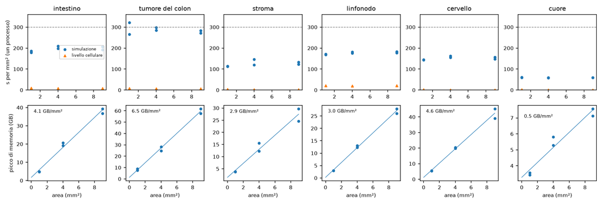

Crescita con l’area, quadrati pieni, tutti gli strati, due semi, al più 6 processi. In alto: secondi per mm² della simulazione (cerchi) e del livello cellulare (triangoli); tratteggio, bilancio di 300 s per mm². In basso: picco di memoria della simulazione, con la retta dei minimi quadrati.

**Cosa guardare**: il tempo per mm² resta piatto da 1 a 9 mm² in tutti i tessuti; la memoria cresce in linea retta, da 0.5 GB per mm² nel cuore a 6.5 nel tumore del colon.

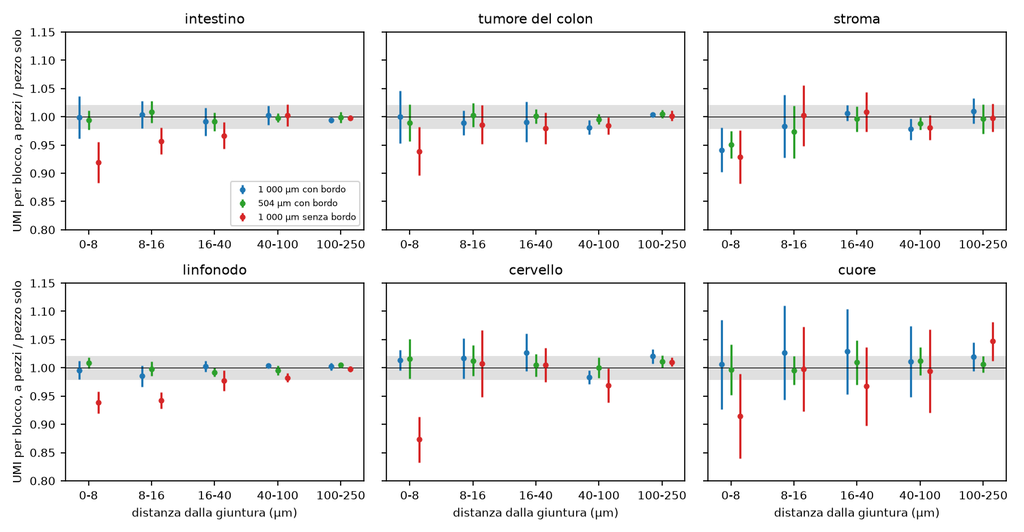

Giunture, quadrati di 4 mm² a strisce spente, 3 semi per disegno: UMI medio per blocco di 8 µm a pezzi diviso il pezzo solo, per distanza dalla giuntura, con ± 2 errori standard. Banda grigia: margine di ± 2 %.

**Cosa guardare**: con il bordo (blu, verde) i punti stanno sull’1 ma le barre superano spesso il margine (precisione di 3 semi); senza bordo (rosso) il primo blocco cala in tutti i tessuti. Nello stroma il calo con bordo è il caso (PH-2).

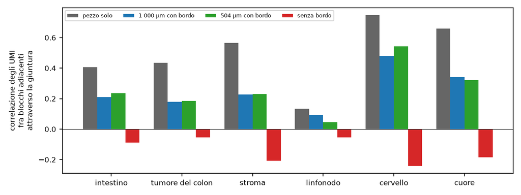

Correlazione degli UMI fra blocchi adiacenti attraverso la giuntura (media di 3 semi), pezzo solo e tre disegni a pezzi.

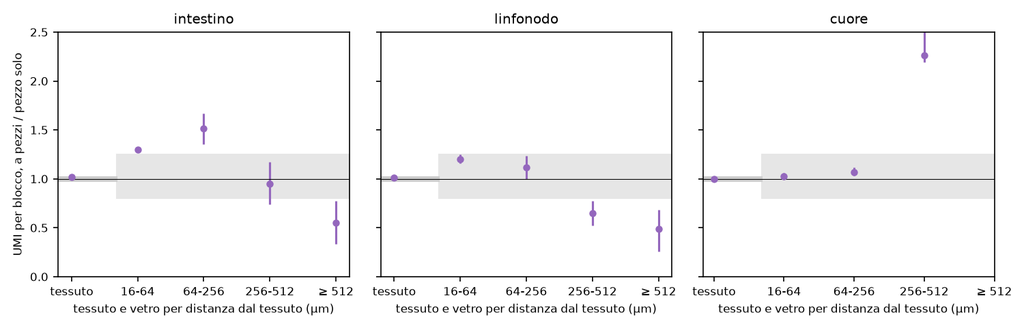

Sezioni intere, a pezzi di 1 000 µm diviso il pezzo solo: tessuto e vetro per distanza dal tessuto, intervallo percentile del bootstrap delle tessere di 500 µm. Grigio scuro: margine del tessuto (± 2 %); grigio chiaro: margine del vetro (0.8-1.25).

**Cosa guardare**: nell’intestino e nel linfonodo il vetro lontano a pezzi ha la metà dei trascritti e quello vicino ne ha di più; nel cuore coincidono, salvo la fascia 256-512 µm (108 blocchi all’angolo dell’area di cattura, PH-3).

## Tutti i giudizi

Tabella `results/S2.6/S2.6_verdicts.csv`.

| id | tessuto | quantità | stima | intervallo (± 2 SE o percentile) | intervallo di rilevanza | esito |
| --- | --- | --- | --- | --- | --- | --- |
| P-1 | intestino | Step 1, tempo per mm2 9/1 | 0.923 | [0.8889, 0.9571] | [0.8, 1.25] | confermata |
| P-2a | intestino | simulazione, tempo per mm2 9/1 | 1.092 | [0.9655, 1.218] | [0.8, 1.25] | confermata |
| P-2b | intestino | memoria aggiunta per mm2, 4-9 / 1-4 | 0.7277 | [0.4953, 0.9601] | [0.8, 1.25] | indeterminata |
| P-4b | intestino | un pezzo solo, s per mm2 utile (9 mm2) | 199.5 | [184.8, 214.2] | [0, 300] | confermata |
| P-1 | tumore del colon | Step 1, tempo per mm2 9/1 | 0.8978 | [0.8715, 0.924] | [0.8, 1.25] | confermata |
| P-2a | tumore del colon | simulazione, tempo per mm2 9/1 | 0.9572 | [0.7386, 1.176] | [0.8, 1.25] | indeterminata |
| P-2b | tumore del colon | memoria aggiunta per mm2, 4-9 / 1-4 | 1.113 | [0.7125, 1.513] | [0.8, 1.25] | indeterminata |
| P-4b | tumore del colon | un pezzo solo, s per mm2 utile (9 mm2) | 278 | [266.5, 289.6] | [0, 300] | confermata |
| P-1 | stroma | Step 1, tempo per mm2 9/1 | 0.7047 | [0.6986, 0.7108] | [0.8, 1.25] | smentita |
| P-2a | stroma | simulazione, tempo per mm2 9/1 | 1.133 | [1.038, 1.227] | [0.8, 1.25] | confermata |
| P-2b | stroma | memoria aggiunta per mm2, 4-9 / 1-4 | 0.8507 | [0.07384, 1.627] | [0.8, 1.25] | indeterminata |
| P-4b | stroma | un pezzo solo, s per mm2 utile (9 mm2) | 128.1 | [118.9, 137.4] | [0, 300] | confermata |
| P-1 | linfonodo | Step 1, tempo per mm2 9/1 | 0.9822 | [0.9586, 1.006] | [0.8, 1.25] | confermata |
| P-2a | linfonodo | simulazione, tempo per mm2 9/1 | 1.065 | [1.019, 1.112] | [0.8, 1.25] | confermata |
| P-2b | linfonodo | memoria aggiunta per mm2, 4-9 / 1-4 | 0.8894 | [0.6451, 1.134] | [0.8, 1.25] | indeterminata |
| P-4b | linfonodo | un pezzo solo, s per mm2 utile (9 mm2) | 180.5 | [175.3, 185.7] | [0, 300] | confermata |
| P-1 | cervello | Step 1, tempo per mm2 9/1 | 0.4868 | [0.4836, 0.4899] | [0.8, 1.25] | smentita |
| P-2a | cervello | simulazione, tempo per mm2 9/1 | 1.051 | [1.004, 1.099] | [0.8, 1.25] | confermata |
| P-2b | cervello | memoria aggiunta per mm2, 4-9 / 1-4 | 0.905 | [0.6938, 1.116] | [0.8, 1.25] | indeterminata |
| P-4b | cervello | un pezzo solo, s per mm2 utile (9 mm2) | 152.1 | [143.8, 160.4] | [0, 300] | confermata |
| P-1 | cuore | Step 1, tempo per mm2 9/1 | 0.4534 | [0.4331, 0.4737] | [0.8, 1.25] | smentita |
| P-2a | cuore | simulazione, tempo per mm2 9/1 | 0.9884 | [0.9727, 1.004] | [0.8, 1.25] | confermata |
| P-2b | cuore | memoria aggiunta per mm2, 4-9 / 1-4 | 0.564 | [0.09753, 1.03] | [0.8, 1.25] | indeterminata |
| P-4b | cuore | un pezzo solo, s per mm2 utile (9 mm2) | 59.35 | [58.88, 59.82] | [0, 300] | confermata |
| P-3 | intestino | memoria di un pezzo del disegno (GB) | 5.208 | [4.97, 5.447] | [0, 8] | confermata |
| P-4a | intestino | disegno, s per mm2 utile | 823 | [799.4, 846.6] | [0, 300] | smentita |
| P-3 | tumore del colon | memoria di un pezzo del disegno (GB) | 8.891 | [7.567, 10.22] | [0, 8] | indeterminata |
| P-4a | tumore del colon | disegno, s per mm2 utile | 1325 | [1107, 1542] | [0, 300] | smentita |
| P-3 | stroma | memoria di un pezzo del disegno (GB) | 4.336 | [4.179, 4.492] | [0, 8] | confermata |
| P-4a | stroma | disegno, s per mm2 utile | 527.2 | [515.4, 539.1] | [0, 300] | smentita |

[output cut: 97 more lines]

# Correzioni dopo il calcolo

- **C-1, scheduler**: con le domande 2 e 3 lanciate insieme, i compiti della domanda 2 dipendevano dai livelli della domanda 1, esclusi dall’elenco: la domanda 2 non partiva. Corretto `tools/S2.6_run.py` (le dipendenze si cercano in tutte le domande); domanda 2 lanciata a parte con al più 9 processi e 60 GB previsti.
- **C-2, somme del lato vero**: `np.add.reduceat` falliva con colonne vuote in coda alla matrice (linfonodo, cervello); sostituito con la somma cumulativa (stessi valori dove funzionava).
- **C-3, bootstrap delle sezioni** (revisione G-5): i ricampioni con somma nulla sul lato del pezzo solo valevano 0; ora sono esclusi (non definiti). Gli esiti si giudicano con l’intervallo percentile del bootstrap, come dice il protocollo per le quantità derivate, non con la sua semi-ampiezza maggiore resa simmetrica. Cambia un solo esito: CP-2, cuore, 256-512 µm, da indeterminata a smentita.

# Analisi post hoc

- **PH-1, stroma con un bordo che copre tutta l’area** (`/mnt/micron/geo_spatialtrans/S2.6/ph1/`, semi da 20261216): ogni pezzo simula l’intero quadrato di 4 mm² e tiene solo la sua parte; nessun difetto di giuntura è possibile. Fascia 0-8 µm 301.0, 281.1, 297.7 UMI per blocco (media 293.3) contro 307 dei 3 semi del pezzo solo: la differenza di P-5 non dipende dalla geometria dei pezzi.
- **PH-2, sei semi in più del pezzo solo nello stroma** (`/mnt/micron/geo_spatialtrans/S2.6/ph2/`, semi da 20261217): fascia 0-8 µm 274.9, 302.3, 285.3, 289.3, 312.6, 284.4; con i 9 semi la media è 296.6 (deviazione standard fra semi 14.1, 4.7 %). I 3 semi di partenza (306.9) erano alti per caso. Con i 9 semi il rapporto è 0.974 ± 0.037 (1 000 µm) e circa 0.99 (504 µm). La smentita di P-5 è spiegata. Lezione: con la variabilità fra semi delle fasce, 3 semi danno errori standard poco affidabili (BL-245).
- **PH-3, vetro vicino al bordo dell’area di cattura** (`tools/S2.6_PH3_edge.py`, `S2.6_PH3_edge.csv`): vetro a 16-256 µm dal tessuto, a pezzi / pezzo solo, entro 300 µm dal bordo dell’area di cattura contro oltre: intestino 1.71 contro 1.31, linfonodo 1.35 contro 1.12, cuore 1.08 contro 1.02; cuore, vetro oltre 256 µm vicino al bordo 57 contro 26 UMI. Nei pezzi la coda si riflette anche sul bordo dell’area di cattura, nel pezzo solo si perde: spiega CP-2.

# Revisione avversariale

Tre sotto-agenti con codice proprio, dai file grezzi (2026-11-10):

- **Giunture**: J-1, J-2, J-3 di 4 esecuzioni (pezzo solo dello stroma con giunture virtuali a 1 000 e 504 µm, pezzi di 504 µm dello stroma, linfonodo senza bordo, intestino con bordo) e degli ingressi di P-5 nello stroma: 95 confronti, tutti entro 6e-15 relativo; PH-2 ricalcolato. Rilievi senza effetto sugli esiti: la regola delle giunture `round(lato / T) - 1` vale per i lati di S2.6 ma non in generale; la quota J-2 esclude il fondo dal denominatore; ramo morto per pezzi non multipli di 8 µm.
- **Sezioni**: fasce di linfonodo e cuore (80 quantità deterministiche, entro 5e-16) e tempi e picchi delle sezioni (21 valori); la correzione del livello del linfonodo tocca solo il territorio della cellula 624286. Due rilievi, entrambi accolti: il bootstrap con 0/0 (correzione C-3); l’esito del vetro a 16-64 µm del linfonodo (confermata) è a ridosso: con altri semi del bootstrap l’estremo superiore va da 1.245 a 1.251 contro 1.25.
- **Risorse**: 46 giudizi di P-1…P-4, P-8 ricalcolati, identici; semi dichiarati 101/101; lettura dello strumento dei pezzi contro questo file senza discrepanze. Rilievi: unità dei GB non dichiarata (qui GB = 1024³ byte; in GB decimali P-3 nel tumore sarebbe smentita); P-2b con 2 semi ha un errore standard a un grado di libertà (tutti gli abbinamenti dei semi danno 0.33-0.80 nel cuore e 0.61-0.84 nell’intestino, sotto 0.8); il tempo dei pezzi del disegno non comprende il ritaglio (sottostima piccola, esito smentito comunque).

# Cosa è girato

- Commit: cancelli `ffc521d`, ok di Luca `ee928fb`, calcolo e chiusura nel commit «S2.6: esiti, revisione, In breve, decisioni DEC-072 e DEC-073, BACKLOG, report».
- Script: `tools/S2.6_run.py` (pannello), `tools/S2.6_pieces.R`, `tools/S2.6_explore.R`, `tools/S2.6_section_layer.R`, `tools/S2.6_measures.R`, `tools/S2.6_section_measures.py`, `tools/S2.6_analysis.py`, `tools/S2.6_report_parts.py`; post hoc `tools/S2.6_PH3_edge.py` (PH-1 e PH-2 con `tools/S2.6_pieces.R`, semi da 20261216 e 20261217).
- Semi: livelli dei quadrati 20261209; simulazioni della domanda 1 20261210; domanda 2 20261211; pezzi del disegno 20261212; livelli delle sezioni 20261213; simulazioni delle sezioni 20261214; bootstrap 20261215 (B = 2000).
- Durata: 52 ore-processo, circa 7 ore e 45 minuti di orologio (2026-11-10, dalle 06:35 alle 14:20, più le analisi successive), fino a 25 processi, temperatura massima 84 °C.
- md5: 69 file letti identici prima e dopo (`results/S2.6/S2.6_md5_before.txt`, `S2.6_md5_after.txt`); `R/` invariato.

## Esplorazioni prima della pre-registrazione

Seme 20261201, uscite in `/mnt/micron/geo_spatialtrans/S2.6/explore/`, macchina libera salvo dove detto; non sono risultati dello step.

- **E-1, pixel della maschera** (`tools/S2.6_explore.R pc`): quadrato pieno di 1 mm², linfonodo con pixel di 8, 2, 1, 0.274 µm: 28 096 cellule a 8, 2 e 1 µm (livelli identici bit per bit fra 8 e 2 µm), 28 101 a 0.274 µm; 20.5-20.7 s e 0.76-0.81 GB, 26.3 s e 1.39 GB a 0.274 µm. Intestino: 12 419 cellule, 8.8 s a 8 e 2 µm; 15.4 s a 0.274 µm. **Decisione tecnica**: quadrati con pixel di 2 µm.
- **E-2, crescita della simulazione** (tumore, quadrato pieno, un seme, due processi in parallelo): 1 mm² 69.3 milioni di trascritti generati, 271 s, 8.8 GB; 4 mm² 280 milioni, 1 096 s, 28.8 GB. Livello cellulare 7.2 s e 26.3 s.
- **E-3, strumento dei pezzi** (`tools/S2.6_pieces.R`, cuore, quadrato di 400 µm): un pezzo unico con le ancore e senza bordo riproduce `simulate_visium_hd()` bit per bit (230 400 quadratini); diventato il test T1 di G-1.
- **E-4, livello cellulare delle sezioni** (`tools/S2.6_section_layer.R`): cuore 42 115 cellule, 52 s, 1.0 GB; linfonodo 631 279 cellule, 1 581 s, 11.1 GB, di cui 1 123 s nella tassellazione (sul quadrato pieno da 1 mm² la tassellazione di 28 000 cellule prende 2.4 s: con il bordo a gradini della maschera la crescita è molto più che lineare). Area del tessuto del livello = area di Space Ranger (22.47 e 42.63 mm²).
- **E-5, quadrati di 1 mm², tutti gli strati** (quattro processi in parallelo): intestino 206 s, 5.8 GB; linfonodo 177 s, 3.2 GB; cervello 174 s, 7.1 GB; cuore 57 s, 3.5 GB; tumore a strisce spente 132 s, 3.6 GB (12.0 milioni di trascritti invece di 69.3: la sovra-generazione delle strisce moltiplica i trascritti per 3-6). Lo stroma non è girato (strumento riscritto durante l’esecuzione: errore di sintassi, rilanciato nel pannello).
- **E-6, giunture** (linfonodo, quadrato di 4 mm², strisce spente, un seme, fino a 9 processi): UMI medio per blocco di 8 µm nella fascia 0-8 µm dalla giuntura rispetto al pezzo solo: pezzi di 1 000 µm con bordo 1.003, pezzi di 500 µm con bordo 1.007, **senza bordo 0.924**; fasce oltre 16 µm entro l’1 % in tutti i disegni. Trascritti nati da cellule di un altro pezzo: 15.5 % nella fascia 0-8 µm (2.1 % in tutto) con pezzi di 1 000 µm, 21.6 % (4.5 %) con pezzi di 500 µm. Correlazione degli UMI fra blocchi adiacenti attraverso la giuntura: pezzo solo 0.147, pezzi con bordo 0.007, senza bordo −0.091. Con pezzi di 500 µm le coppie attraverso la giuntura non sono adiacenti (blocco tagliato): da qui i pezzi di 504 µm.

## Attese pre-registrate

Commit dei cancelli: `ffc521d` («S2.6: perimetro, esplorazioni, strumenti, cancelli»). Ok di Luca sulle previsioni P-1…P-8, sulle soglie (2 % alle giunture e nel tessuto della sezione; un quarto per la crescita; bilancio del documento di progetto; 0.8-1.25 per il vetro), sulle regole R-1 e R-2, sulle controprove e sul calcolo di circa 44 ore-processo: 2026-11-10, «Ok, come proposte (Recommended)».

Semi (Mersenne-Twister, `sample.int(1e8, n)`): livelli dei quadrati da 20261209 (ordine: tessuto A1…A6, lato 1 000, 2 000, 3 000 µm, seme k = 0, 1); simulazioni in un pezzo solo della domanda 1 da 20261210 (stesso ordine); pezzi del disegno della domanda 1 da 20261212 (tessuto, pezzo); domanda 2 da 20261211 (tessuto, disegno ONE, P1000, P504, P1000H0, k = 0, 1, 2); livelli delle sezioni da 20261213; simulazioni delle sezioni da 20261214 (sezione, in un pezzo solo / a pezzi); dentro un’esecuzione a pezzi il seme di ogni pezzo è estratto dal seme dell’esecuzione. Bootstrap B = 2000, seme 20261215. Processi: al più 20 a un thread (limite termico, file `WORKERS` e guardia della temperatura come in S2.0), memoria prevista totale al più 180 GB. Uscite in `/mnt/micron/geo_spatialtrans/S2.6/` (un file per esecuzione e per pezzo, rilanciabile); tabelle in `results/S2.6/`.

# Gli strumenti

- `tools/S2.6_pieces.R`: `one` (simulazione in un pezzo solo; per i quadrati `frame_open = TRUE`, per le sezioni intere `FALSE`) e `pieces` (pezzi: area utile U di lato T, riquadro = U allargato del bordo H e tagliato al riquadro dell’area intera; cellule con il centro nel riquadro; territori e nuclei tagliati al riquadro; regioni intersecate; quattro ancore di 1e-4 µm agli angoli del riquadro, così la griglia del pezzo è allineata a quella dell’area intera e la riflessione della seconda coda avviene sui lati del riquadro; `frame_open = TRUE` in ogni pezzo; si tengono i quadratini con il centro in U, più il margine di vetro sui lati dell’area intera; seme del pezzo estratto dal seme dell’esecuzione). Un pezzo senza cellule non si simula (oggi `simulate_stripes()` richiede tessuto): i suoi quadratini restano a zero.
- `tools/S2.6_section_layer.R`: livello cellulare della sezione dalla maschera di Space Ranger a 8 µm (pixel di 8 µm), più quattro ancore agli angoli dell’area di cattura [0, 6 704] µm.
- `tools/S2.6_explore.R pc`: livello cellulare di un quadrato pieno (pixel di 2 µm). Argomenti di `place_cells()` come i livelli U6 di S1.6 in tutti i casi.
- `tools/S2.6_measures.R`: misure delle giunture (sotto).

# Definizioni delle misure

- **Tempo**: tempo di orologio della chiamata (`place_cells()`, `simulate_visium_hd()`, o di ogni pezzo); **memoria**: picco del processo (VmHWM). Per i pezzi la memoria è quella del processo figlio che simula il pezzo. Costo per mm² utile = somma dei tempi dei pezzi / area utile.
- **Giunture** (domanda 2): blocchi di 8 µm della griglia dell’area intera con il centro nel quadrato; distanza di un blocco = distanza del centro dalla giuntura interna più vicina; fasce 0-8, 8-16, 16-40, 40-100, 100-250 µm. Nel pezzo solo le stesse linee sono giunture virtuali. **J-1**: UMI medio per blocco nella fascia; rapporto (media dei 3 semi a pezzi) / (media dei 3 semi in un pezzo solo), errore standard col metodo delta dalle deviazioni standard fra semi. **J-2**: quota dei trascritti catturati nella fascia nati da cellule del bordo (cellule simulate anche in un altro pezzo, con un’altra realizzazione). **J-3**: coppie di blocchi adiacenti da lati opposti di una giuntura: correlazione di Pearson degli UMI e coseno medio dei vettori dei geni.
- **Sezione intera** (domanda 3): blocchi di 8 µm dell’area di cattura; tessuto = maschera di Space Ranger; vetro per distanza dal tessuto (16-64, 64-256, 256-512, oltre 512 µm, come S2.4 P-5, distanza fra centri dei blocchi); esclusi i 50 µm al bordo dell’area di cattura. Rapporto a pezzi / in un pezzo solo dell’UMI medio per blocco, intervallo dal bootstrap delle tessere di 500 µm (come S2.4 P-5), B = 2000. Lato vero (descrittivo): matrice di Space Ranger a 8 µm di tutti i blocchi, stesse fasce.

# Regole di decisione dei dati (scritte prima del calcolo)

**R-1, sezione intera in un pezzo solo.** Si simula in un pezzo solo una sezione il cui picco previsto (0.092 GB per milione di trascritti generati + 0.87 GB per mm² di tessuto, dal tumore a 1 mm² con e senza strisce, E-2 ed E-5; trascritti generati per mm² dai quadrati di 1 mm² di E-5) non supera 120 GB; una alla volta, con un controllo che ferma il processo oltre 200 GB. Previsto: intestino circa 100 GB, linfonodo circa 47, cuore circa 49 (si fanno); cervello circa 154, tumore circa 240 (non si fanno: per loro la sezione intera è solo a pezzi).

**R-2, lo step successivo** (decisione dei dati con la delega di Luca, Dopo S2.5 si fa prima una prova di prestazione su aree grandi; ordine e perimetro delle sessioni successive li prepara l’agente (DEC-071)). In ordine:

1. Se P-8 è smentita per il tempo in almeno una sezione, il livello cellulare va ottimizzato prima (id proposto S1.7).
2. Altrimenti, se fra P-3, P-4 (disegno del documento di progetto), P-5, P-6 e P-7 c’è almeno un esito smentito, lo step successivo è la simulazione a pezzi corretta dentro il pacchetto (S2.7), con le richieste che gli esiti indicano: niente bordo simulato due volte se P-3 o P-4 falliscono; seconda coda trattata sull’area intera se P-6 o P-7 falliscono; giunture corrette se P-5 fallisce.
3. In ogni caso S2.7 deve dare a ogni cellula una sola realizzazione e strisce dell’area intera: oggi non è così per costruzione (J-2, strisce per pezzo). Se nessun esito è smentito, questi due difetti si portano a Luca come scelta (limite dichiarato oppure S2.7).

# Cancelli (al massimo 5)

| id | controllo | tolleranza | comando |
| --- | --- | --- | --- |
| G-1 | **batteria degli strumenti** (33 asserzioni): un pezzo unico senza bordo = `simulate_visium_hd()` bit per bit (cuore, tumore: UMI per quadratino, matrice a 8 µm, origine); con bordo, ogni quadratino d… | identità esatte; mutanti 8/8 | `R_LIBS_SITE=/nonexistent R_LIBS_USER=/nonexistent Rscript --vanilla R/testing/test_S2.6.R`; `.venv/bin/python tools/S2.6_mutants.py` |
| G-2 | **invarianti di ogni esecuzione**: griglia del pezzo allineata (altrimenti lo strumento si ferma), copertura una volta, UMI cuciti = somma dei pezzi, 8 µm = somma dei 2 µm, nessun NA, conservazione di… | identità | `tools/S2.6_check.R` |
| G-3 | **riproducibilità**: un’esecuzione a pezzi (cuore, 504 µm, k = 0) rifatta con un numero di processi diverso e misure rifatte | md5 identici (UMI, matrice, tabelle delle misure) | `tools/S2.6_repro.sh` |
| G-4 | **integrità**: md5 dei file letti prima e dopo (maschere e matrici delle cinque sezioni, parametri dei preset); `git diff` vuoto su `R/` salvo `R/testing/test_S2.6.R`; batterie di S2.1…S2.5 invariate | identità | `tools/S2.6_md5.sh before / after`; batterie |
| G-5 | **revisione avversariale**: sotto-agenti con codice proprio ricalcolano (a) J-1, J-2, J-3 di due esecuzioni dai file grezzi; (b) le fasce del vetro di una sezione; (c) tempi e memoria dalle tabelle pe… | quantità deterministiche entro 1e-9 relativo; ogni discrepanza è un dubbio | sotto-agenti, report |

Correzioni prima dei cancelli (dichiarate): (1) la prima stesura della batteria non vedeva due mutanti: sul disco di prova il tessuto toccava tutti i lati di ogni riquadro (le ancore non cambiavano nulla) e nel caso sintetico il deficit restava nella fascia 0-8 µm anche spostando le giunture; ora due dischi lontani e un deficit asimmetrico. (2) Un territorio tangente al lato del riquadro dava, tagliato, poligono più segmento (errore di GEOS «mixed-dimension» nei pezzi senza bordo): lo strumento tiene solo la parte poligonale. (3) Durante E-5 lo strumento è stato riscritto mentre girava (stroma non eseguito): da qui in poi gli strumenti non si toccano durante un’esecuzione.

# Previsioni

Esito come da protocollo: stima ± 2 errori standard tutta dentro l’intervallo, confermata; tutta fuori, smentita; a cavallo, indeterminata.

| id | quantità | tessuti | atteso | intervallo di rilevanza | fonte dell’intervallo | 2 errori standard tipici |
| --- | --- | --- | --- | --- | --- | --- |
| P-1 | livello cellulare, tempo per mm² a 9 mm² / a 1 mm² (quadrati pieni) | A1-A6 | confermata 6/6 (E-2: 0.92 fra 4 e 1 mm²) | [0.8, 1.25] | da approvare: la precisione che serve per pianificare (un tempo stimato sbagliato di un quarto non cambia macchina né numero di processi) | pochi percento (2 semi) |
| P-2 | simulazione in un pezzo solo: (a) tempo per mm² a 9 / a 1 mm²; (b) memoria aggiunta per mm² fra 4 e 9 mm² / fra 1 e 4 mm² (crescita lineare, su cui si basano R-1 e le stime delle sezioni) | A1-A6 | attesa: (a) confermata 6/6; (b) confermata 6/6. Base debole, dichiarata: una sola coppia di aree misurata (tumore, 1 e 4 mm², E-2: tempo 1.01, memoria aggiunta 6.7 GB per mm²); nessuna misura oltre 4 … | [0.8, 1.25] | come P-1 | pochi percento |
| P-3 | memoria di un pezzo del disegno del documento di progetto (504 µm, bordo 280 µm, tutti gli strati) | A1-A6 | attesa (estrapolazione lineare dai quadrati di 1 mm² di E-5; lo stroma è stimato dal rapporto stroma/tumore delle aree di S2.5, non misurato): confermata intestino (circa 6.3 GB), stroma (5.7), linfon… | [0, 8 GB] | bilancio del documento di progetto, sezione 12 | pochi percento (4 pezzi) |
| P-4 | costo per mm² utile: (a) disegno del documento di progetto; (b) un pezzo solo a 9 mm² | A1-A6 | attesa (come P-3; stroma stimato): (a) **smentita** intestino (circa 920 s), tumore (1 210), stroma (540), linfonodo (790), cervello (780); indeterminata cuore (250); (b) confermata 5/6, indeterminata… | [0, 300 s] | bilancio del documento di progetto, sezione 12 (1 mm² in 5 minuti) | pochi percento |
| P-5 | J-1, a pezzi / pezzo solo, cinque fasce, pezzi di 1 000 e 504 µm con bordo | A1-A6 | confermata in tutte le fasce (E-6: 0.99-1.01); nel cuore possibile indeterminata (poche cellule grandi) | **[0.98, 1.02]** | da approvare: la precisione del lato simulato in S2.5 (1-3 %): uno scarto più piccolo non è distinguibile con le verifiche che abbiamo fatto del simulatore | circa 1 % (E-6) |
| P-6 | vetro della sezione intera, a pezzi / pezzo solo, quattro fasce | A1, A4 (coda lunga 1.6-1.8 mm) | oltre 512 µm **smentita per difetto** (i pezzi senza cellule restano a zero; la coda resta nel riquadro del pezzo); 256-512 µm indeterminata o smentita; 16-256 µm confermata o smentita per eccesso (co… | [0.8, 1.25] | Luca, 2026-10-31 (R5 CP-2), usato in S2.3 P-4 e S2.4 P-5 | bootstrap delle tessere |
| P-7 | UMI medio per blocco nel tessuto della sezione intera, a pezzi / pezzo solo | A1, A4, A6 | confermata o indeterminata (la coda ripiegata resta nel tessuto: + 1-1.5 % nell’intestino e nel linfonodo) | [0.98, 1.02] | come P-5 | bootstrap delle tessere |
| P-8 | livello cellulare della sezione intera: (a) tempo per mm² di tessuto; (b) picco di memoria | 5 sezioni | (a) confermata 5/5 (linfonodo 70 s per mm², E-4); (b) **smentita nel linfonodo** (11.1 GB, E-4), confermata nel cuore (1.0 GB), indeterminata o confermata altrove | (a) [0, 300 s]; (b) [0, 8 GB] | bilancio dello Step 1 (C11) e del documento di progetto, sezione 12 | un solo seme: nessun errore Monte Carlo, si dice |

Il cuore non è qui un controllo negativo del Voronoi isotropo: nessuna misura di questo step dipende dalla forma delle cellule.

# Controprove

- **CP-1, la misura delle giunture vede un difetto quando c’è?** Pezzi di 1 000 µm senza bordo: J-1 nella fascia 0-8 µm smentita per difetto 6/6 (E-6: 0.924 nel linfonodo). Se in un tessuto non lo è, lì P-5 non ha potere.
- **CP-2, il confronto del vetro non inventa differenze?** Cuore (coda di 113 µm): vetro a pezzi / pezzo solo confermato in tutte le fasce con vetro. Se è smentito, il confronto del vetro ha un errore suo.

# Misure (senza intervallo)

- J-2 e J-3 per tessuto e disegno; tempo per fase dello Step 1 (tassellazione) e della simulazione; esponente di crescita.
- Sezione intera: tempo totale di processo e di orologio, memoria massima per pezzo, pezzi senza cellule; picco della sezione in un pezzo solo contro la previsione di R-1.
- Descrittive contro la sezione vera (BL-205): UMI medio per blocco nel tessuto, vetro per fascia (simulato / vero), per le sezioni a pezzi e in un pezzo solo.

# Stima dei tempi (dell’agente, dalle esplorazioni)

Domanda 1: circa 9 ore-processo (simulazioni in un pezzo solo 7.8, pezzi del disegno 1.3, livelli cellulari 0.3). Domanda 2: circa 13 ore-processo. Domanda 3: circa 21 ore-processo (livelli cellulari 1, pezzo solo 3.7, a pezzi 16.5). In tutto **circa 44 ore-processo**, poco sopra le 20-40 della preparazione; con 16-20 processi circa 3-4 ore di orologio, limitate dalle simulazioni grandi in un pezzo solo (fino a 100 GB, una alla volta).

## Deviazioni dichiarate

- **D-1, rete**: la VPN è caduta durante il calcolo; si è continuato dal secondo accesso allo stesso server (lesexp-ts), come chiesto da Luca.
- **D-2, una cellula corretta** (`tools/S2.6_fix_cell.R`): nel livello della sezione del linfonodo il territorio della cellula 624286 aveva uno spigolo di 8e-5 µm su cui la triangolazione vincolata di GEOS fallisce (`place_and_move_transcripts()`, «Unable to find a convex corner»), e la simulazione in un pezzo solo si fermava dopo 70 minuti. Su tutte le cellule dei 5 livelli delle sezioni e dei 12 quadrati di 9 mm² è l’unica geometria che fallisce (`tools/S2.6_tri_scan.R`). Il solo territorio è stato semplificato con tolleranza 1e-4 µm (area +0.00033 µm², nucleo invariato); l’originale è in `sec_A4_s34235060_orig.rds`; le due simulazioni del linfonodo usano il livello corretto; P-8 usa tempo e memoria del livello originale. Difetto del pacchetto, rinviato (BL-241).
- **D-3, processi**: domanda 1 con al più 6 processi; domande 2 e 3 insieme fino a 25 processi (16 + 9) (guardia della temperatura, massimo 84 °C), in parte accanto a lavori di altri utenti (due esecuzioni di tesi): i tempi delle domande 2 e 3 sono a macchina carica. La domanda 2 è girata senza guardia della temperatura (9 processi fissi).
- **D-4, un seme per le sezioni**: come pre-registrato; l’incertezza delle sezioni è quella del bootstrap delle tessere.
- **D-5, calcolo**: 52 ore-processo (domanda 1: 9.3, 2: 15.7, 3: 25.2, post hoc 1.9) contro le 44 previste; più la simulazione del linfonodo fallita (circa 1.2 ore).

# Appendice: da dove vengono i numeri del riassunto

| frase del riassunto | fonte (tabella o file, riga) | valore letto |
| --- | --- | --- |
| da 1 minuto per mm² nel cuore a 4 minuti e mezzo nel tumore | `S2.6_verdicts.csv`, P-4b, cuore e tumore | 59.4 s; 278 s |
| intestino 107 GB, quasi 2 ore; linfonodo 87 GB; cuore 26 GB | `S2.6_q3_runs.csv`, one_peak_gb, one_s | 107.4 GB, 6 830 s; 87.4 GB; 26.3 GB |
| 251 GB del server | `free -g` sul server | 251 |
| 7,6 volte sul linfonodo intero, 3-6 volte sui quadrati di 9 mm² | `q3/one_A4/run.json` M; `S2.6_q1_runs.csv` M a 3 000 µm | 7.58; 3.38-5.63 |
| 4,5 volte l’area utile | `q1/design_*/cut.json`: box_mm2 / useful_mm2 | 1.132 / 0.254 = 4.46 |
| da quasi 2 a più di 4 volte il bilancio, in cinque tessuti su sei | `S2.6_verdicts.csv`, P-4a | 527-1 325 s contro 300; cuore 272 s confermata |
| da 2 a 7 ore-processo per sezione con pezzi da 1 mm | `S2.6_q3_runs.csv`, pieces_process_s | 7 289 s (cuore), 25 128 s (tumore) |
| da un sesto a due quinti dei trascritti accanto alla giuntura | `S2.6_q2_J1_J2.csv`, dup_frac, fascia 0-8, P1000 e P504 | 0.161-0.392 |
| la somiglianza cala da un terzo a più della metà | `S2.6_q2_J3.csv`, pearson, ONE contro P1000 | linfonodo 0.134 → 0.093; stroma 0.566 → 0.228 |
| senza bordo calano dal 6 al 13 % | `S2.6_verdicts.csv`, CP-1 | 0.873-0.939 |
| nel linfonodo entro il 2 % in 8 fasce su 10 | `S2.6_verdicts.csv`, P-5, linfonodo | 8 confermate, 2 indeterminate |
| calo del 5 % nello stroma, con nove semi sparisce | `S2.6_verdicts.csv` P-5 stroma 504 µm 0-8; PH-2 | 0.951 ± 0.024; 9 semi 0.974 ± 0.037 (1 000 µm) |
| senza bordo il calo si vede in quattro tessuti su sei | `S2.6_verdicts.csv`, CP-1 | 4 smentite, 2 indeterminate |
| vetro oltre mezzo millimetro: la metà | `S2.6_section_A1.csv`, `S2.6_section_A4.csv`, glass_512plus | 0.548; 0.487 |
| vetro vicino fino alla metà in più | `S2.6_section_A1.csv`, glass_64_256 | 1.513 |
| nel cuore coincidono, salvo un angolo | `S2.6_section_A6.csv`; `S2.6_PH3_edge.csv` | 1.026, 1.069; 256-512 µm 2.26 (100 blocchi su 108 al bordo) |
| un secondo più 0,7 millesimi di secondo per cellula | `S2.6_q1_runs.csv`, retta step1_s contro n_cells | 0.78-1.06 s + 0.62-0.74 ms (linfonodo −0.70 s + 0.74 ms) |
| intestino 36 minuti, quasi tutti nel ritaglio | `S2.6_q3_step1.csv`, A1 | 2 172 s; tassellazione 1 876 s |
| linfonodo 10,5 GB | `S2.6_q3_step1.csv`, A4 step1_peak_gb | 10.51 |
| 631 000 cellule, spigolo di meno di un decimillesimo di micron | `tools/S2.6_fix_cell.R` (uscita), `S2.6_tri_scan.R` | 631 291 cellule; spigolo 8e-5 µm, 1 geometria |
| 52 ore-processo (9, 16, 25, 2); 44 stimate | somma dei tempi dei run.json (sessione); stima in docs/steps/S2.6.md | 9.3, 15.7, 25.2, 1.9 |
| 7 ore e tre quarti, fino a 25 processi, sotto 85 °C | `run_q1.log`, `run_q23.log`, `guard.log` | 06:35-14:20; 16 + 9; 84 °C |
| vetro vicino del linfonodo circa tre volte il vero rapportato al tessuto | `S2.6_section_A4.csv`, ratio_one_real | 6.92 / 2.32 = 2.98 |